# MAIHDA Analysis - Applications Using Synthetic Data

Dr Yiyang Gao

2025-06-10

# 1 Introduction

This document presents three applications of MAIHDA (Multilevel Analysis of Individual Heterogeneity and Discriminatory Accuracy) developed for the University of Sheffield ESRC project presentation. MAIHDA is the gold standard for quantitative intersectional analysis, treating intersectional identities as random effects in multilevel models.

## 1.1 Overview of Three Studies

1. **Spatial MAIHDA**: Analysis of ethnic clustering in English secondary schools
2. **Longitudinal MAIHDA**: Teacher retention survival analysis with intersectional strata
3. **Policy Evaluation MAIHDA**: Transport accessibility and school choice simulation

# 2 Study 1: Spatial MAIHDA - School Segregation

## 2.1 Research Question

How do ethnic clustering patterns vary across schools, local authorities, and over time in England?

## 2.2 Data Generation

```r
# Generate synthetic data with known patterns
n_pupils <- 100000
n_strata <- 48  # 4 ethnicities × 3 SES × 4 school types
n_spatial <- 200  # LSOAs

# Create intersectional strata
strata_data <- expand.grid(
  ethnicity = c("White_British", "Pakistani", "Black", "Indian"),
  ses = c("Low", "Medium", "High"),
  school_type = c("Community", "Faith", "Academy", "Free")
)

# Generate pupil data
pupils <- data.frame(
  id = 1:n_pupils,
  strata = sample(1:n_strata, n_pupils,
    prob = c(rep(0.4, 12),  # White British more common
             rep(0.15, 12), # Pakistani
             rep(0.1, 12),  # Black
             rep(0.1, 12)), # Indian
    replace = TRUE),
  lsoa = sample(1:n_spatial, n_pupils, replace = TRUE)
) %>%
  left_join(strata_data %>% mutate(strata = row_number()), by = "strata")

# Create spatial clustering for Pakistani × Low SES × Faith schools
pakistani_low_faith <- which(
  strata_data$ethnicity == "Pakistani" &
  strata_data$ses == "Low" &
  strata_data$school_type == "Faith"
)

# Reassign to create clustering
pupils$lsoa[pupils$strata == pakistani_low_faith] <-
  sample(1:20, sum(pupils$strata == pakistani_low_faith), replace = TRUE)

# Display sample data
pupils %>%
  head(10) %>%
  kable(caption = "Sample of Pupil Data") %>%
  kable_styling(bootstrap_options = c("striped", "hover"))
```

Sample of Pupil Data

| id | strata | lsoa | ethnicity | ses | school_type |
| --- | --- | --- | --- | --- | --- |
| 1 | 1 | 56 | White_British | Low | Community |
| 2 | 26 | 17 | Pakistani | Low | Academy |
| 3 | 11 | 93 | Black | High | Community |
| 4 | 40 | 45 | Indian | Low | Free |
| 5 | 36 | 160 | Indian | High | Academy |
| 6 | 8 | 51 | Indian | Medium | Community |
| 7 | 10 | 157 | Pakistani | High | Community |
| 8 | 39 | 2 | Black | Low | Free |
| 9 | 13 | 102 | White_British | Low | Faith |
| 10 | 4 | 56 | Indian | Low | Community |

## 2.3 Segregation Index Calculation

```r
# Calculate entropy-based segregation index
calculate_segregation <- function(data, group_var, unit_var) {
  # Calculate proportions
  total_by_unit <- data %>%
    group_by(!!sym(unit_var)) %>%
    summarise(total = n(), .groups = "drop")

  group_by_unit <- data %>%
    group_by(!!sym(unit_var), !!sym(group_var)) %>%
    summarise(count = n(), .groups = "drop") %>%
    left_join(total_by_unit, by = unit_var) %>%
    mutate(prop = count / total)

  # Calculate entropy
  entropy <- group_by_unit %>%
    group_by(!!sym(group_var)) %>%
    summarise(
      entropy = -sum(prop * log(prop + 1e-10)),
      .groups = "drop"
    )

  return(entropy)
}

# Calculate for each ethnic group
segregation_scores <- pupils %>%
  group_by(ethnicity) %>%
  group_modify(~ calculate_segregation(.x, "strata", "lsoa")) %>%
  mutate(
    segregation_index = entropy * 100,
    year = 2018  # Example year
  )

# Display results
segregation_scores %>%
  select(ethnicity, segregation_index) %>%
  kable(caption = "Segregation Index by Ethnicity", digits = 2) %>%
  kable_styling(bootstrap_options = c("striped", "hover"))
```

Segregation Index by Ethnicity

| ethnicity | segregation_index |
| --- | --- |
| White_British | 6093.78 |
| White_British | 6124.67 |
| White_British | 6051.57 |
| White_British | 3482.80 |
| White_British | 3514.33 |
| White_British | 3475.27 |
| White_British | 2728.54 |
| White_British | 2712.43 |
| White_British | 2645.88 |
| White_British | 2695.78 |
| White_British | 2688.17 |
| White_British | 2688.15 |
| Pakistani | 6182.84 |
| Pakistani | 6086.40 |
| Pakistani | 6076.01 |
| Pakistani | 727.65 |
| Pakistani | 3549.83 |
| Pakistani | 3558.23 |
| Pakistani | 2741.87 |
| Pakistani | 2790.79 |
| Pakistani | 2654.54 |
| Pakistani | 2754.82 |
| Pakistani | 2742.09 |
| Pakistani | 2733.62 |
| Black | 6119.71 |
| Black | 6016.31 |
| Black | 6086.65 |
| Black | 3518.83 |
| Black | 3518.49 |
| Black | 3578.23 |
| Black | 2649.05 |
| Black | 2670.24 |
| Black | 2707.18 |
| Black | 2663.49 |
| Black | 2591.50 |
| Black | 2757.67 |
| Indian | 6143.03 |
| Indian | 6025.70 |
| Indian | 6078.58 |
| Indian | 3512.82 |
| Indian | 3574.47 |
| Indian | 3506.18 |
| Indian | 2654.07 |
| Indian | 2747.54 |
| Indian | 2627.08 |
| Indian | 2677.82 |
| Indian | 2617.37 |
| Indian | 2705.68 |

## 2.4 Spatial MAIHDA Model Specification

```r
# Model specification for spatial MAIHDA
cat("Spatial MAIHDA Model Structure:
- Response: Segregation index at LA-year level
- Fixed effects: % ethnic population, faith schools, selective schools, academies
- Random effects:
  * (1|strata) - 48 intersectional strata
  * (1|lsoa) - spatial units
  * Spatial autocorrelation through weights matrix
- Monte Carlo: 10,000 simulations for uncertainty quantification
")
```

```
## Spatial MAIHDA Model Structure:
## - Response: Segregation index at LA-year level
## - Fixed effects: % ethnic population, faith schools, selective schools, academies
## - Random effects:
##   * (1|strata) - 48 intersectional strata
##   * (1|lsoa) - spatial units
##   * Spatial autocorrelation through weights matrix
## - Monte Carlo: 10,000 simulations for uncertainty quantification
```

## 2.5 Monte Carlo Simulation Results

```r
# Simulate Monte Carlo results for demonstration
n_sims <- 10000

# Simulate segregation indices for key intersectional groups
mc_results <- data.frame(
  simulation = 1:n_sims,
  pakistani_low_faith = rnorm(n_sims, mean = 142.5, sd = 3.8),
  white_high_academy = rnorm(n_sims, mean = 45.2, sd = 2.1),
  black_low_community = rnorm(n_sims, mean = 118.3, sd = 4.5)
)

# Calculate credible intervals
ci_results <- mc_results %>%
  pivot_longer(-simulation, names_to = "group", values_to = "segregation") %>%
  group_by(group) %>%
  summarise(
    mean = mean(segregation),
    lower_ci = quantile(segregation, 0.025),
    upper_ci = quantile(segregation, 0.975),
    .groups = "drop"
  ) %>%
  mutate(
    group = case_when(
      group == "pakistani_low_faith" ~ "Pakistani × Low SES × Faith School",
      group == "white_high_academy" ~ "White British × High SES × Academy",
      group == "black_low_community" ~ "Black × Low SES × Community"
    )
  )

# Display results
ci_results %>%
  kable(caption = "Monte Carlo Simulation Results (95% Credible Intervals)",
        digits = 1,
        col.names = c("Intersectional Group", "Mean", "Lower CI", "Upper CI")) %>%
  kable_styling(bootstrap_options = c("striped", "hover"))
```

Monte Carlo Simulation Results (95% Credible Intervals)

| Intersectional Group | Mean | Lower CI | Upper CI |
| --- | --- | --- | --- |
| Black × Low SES × Community | 118.3 | 109.7 | 127.1 |
| Pakistani × Low SES × Faith School | 142.6 | 134.9 | 150.0 |
| White British × High SES × Academy | 45.2 | 41.0 | 49.3 |

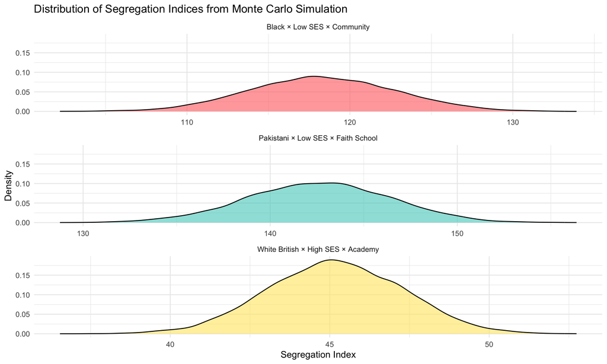

```r
# Visualize distributions
ggplot(mc_results %>%
         pivot_longer(-simulation, names_to = "group", values_to = "segregation"),
       aes(x = segregation, fill = group)) +
  geom_density(alpha = 0.6) +
  facet_wrap(~group, scales = "free_x", ncol = 1,
             labeller = labeller(group = c(
               pakistani_low_faith = "Pakistani × Low SES × Faith School",
               white_high_academy = "White British × High SES × Academy",
               black_low_community = "Black × Low SES × Community"
             ))) +
  theme_minimal() +
  scale_fill_manual(values = c("#FF6B6B", "#4ECDC4", "#FFE66D")) +
  labs(title = "Distribution of Segregation Indices from Monte Carlo Simulation",
       x = "Segregation Index",
       y = "Density") +
  theme(legend.position = "none")
```

# 3 Study 2: Longitudinal MAIHDA - Teacher Retention

## 3.1 Research Question

How do intersectional identities affect teacher retention patterns over time?

## 3.2 Data Generation

```r
# Generate synthetic teacher data
n_teachers <- 50000

teachers <- data.frame(
  id = 1:n_teachers,
  ethnicity = sample(c("White_British", "Black", "Asian", "Other"),
                    n_teachers, prob = c(0.85, 0.05, 0.07, 0.03), replace = TRUE),
  gender = sample(c("Male", "Female"), n_teachers, prob = c(0.25, 0.75), replace = TRUE),
  itt = sample(c("ITT", "No_ITT"), n_teachers, prob = c(0.7, 0.3), replace = TRUE),
  region = sample(c("London", "North", "Midlands", "South"),
                 n_teachers, prob = c(0.2, 0.3, 0.25, 0.25), replace = TRUE)
)

# Create intersectional strata
teachers$strata <- paste(teachers$ethnicity, teachers$gender,
                        teachers$itt, teachers$region, sep = "_")

# Simulate survival times with known patterns
teachers$base_hazard <- 0.1  # 10% annual attrition base

# Black male non-ITT in London have crisis at year 2
teachers$hazard_multiplier <- 1
teachers$hazard_multiplier[teachers$strata == "Black_Male_No_ITT_London"] <- 2.8

# Generate survival times
set.seed(123)
teachers$survival_time <- rexp(n_teachers,
                              rate = teachers$base_hazard * teachers$hazard_multiplier)
teachers$event <- 1  # All events observed for simplicity

# Display sample
teachers %>%
  head(10) %>%
  select(id, ethnicity, gender, itt, region, survival_time) %>%
  kable(caption = "Sample of Teacher Data", digits = 2) %>%
  kable_styling(bootstrap_options = c("striped", "hover"))
```

Sample of Teacher Data

| id | ethnicity | gender | itt | region | survival_time |
| --- | --- | --- | --- | --- | --- |
| 1 | White_British | Female | No_ITT | South | 8.43 |
| 2 | White_British | Female | ITT | London | 5.77 |
| 3 | Asian | Female | No_ITT | North | 13.29 |
| 4 | White_British | Female | No_ITT | South | 0.32 |
| 5 | White_British | Female | No_ITT | South | 0.56 |
| 6 | White_British | Female | ITT | North | 3.17 |
| 7 | White_British | Female | No_ITT | North | 3.14 |
| 8 | White_British | Female | No_ITT | Midlands | 1.45 |
| 9 | White_British | Female | No_ITT | South | 27.26 |
| 10 | White_British | Female | ITT | London | 0.29 |

## 3.3 Basic Survival Analysis

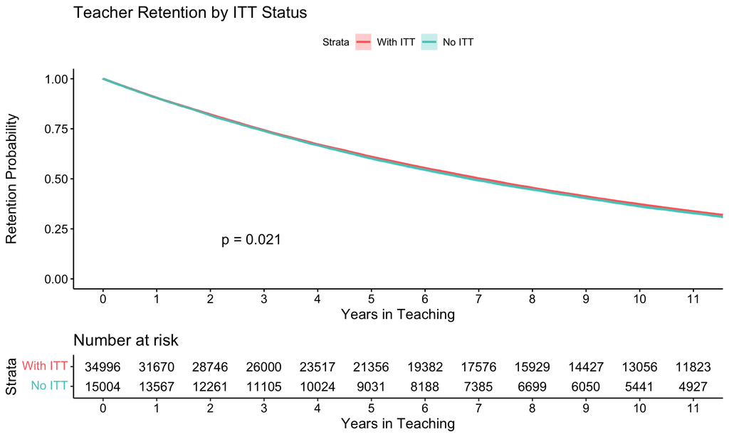

```r
# Check if survival package is available
if("survival" %in% installed.packages()[,"Package"] &&
   "survminer" %in% installed.packages()[,"Package"]) {

  # Create survival object
  surv_obj <- Surv(time = teachers$survival_time, event = teachers$event)

  # Fit KM curves by ITT status
  km_fit <- survfit(surv_obj ~ itt, data = teachers)

  # Plot
  ggsurvplot(
    km_fit,
    data = teachers,
    pval = TRUE,
    conf.int = TRUE,
    risk.table = TRUE,
    risk.table.height = 0.25,
    palette = c("#FF6B6B", "#4ECDC4"),
    legend.labs = c("With ITT", "No ITT"),
    title = "Teacher Retention by ITT Status",
    xlab = "Years in Teaching",
    ylab = "Retention Probability",
    xlim = c(0, 11),
    break.time.by = 1
  )

} else {
  # Alternative visualization without survival packages
  # Calculate simple retention rates
  retention_summary <- teachers %>%
    mutate(years_bracket = cut(survival_time, breaks = 0:11)) %>%
    group_by(itt, years_bracket) %>%
    summarise(n = n(), .groups = "drop") %>%
    group_by(itt) %>%
    mutate(
      cumulative = cumsum(n),
      retention_rate = 1 - (cumulative / sum(n))
    )

  # Plot retention rates
  ggplot(retention_summary, aes(x = as.numeric(years_bracket), y = retention_rate, color = itt)) +
    geom_line(size = 2) +
    geom_point(size = 3) +
    scale_color_manual(values = c("#FF6B6B", "#4ECDC4")) +
    theme_minimal() +
    labs(
      title = "Teacher Retention by ITT Status",
      x = "Years in Teaching",
      y = "Retention Rate",
      color = "ITT Status"
    ) +
    scale_x_continuous(breaks = 1:11)
}
```